# 重賞レース予測レポート【レース終了】

作成日時: 2026/09/13 17:16:13

☞ [マニュアル(pdf)](https://ryutoro-galois.github.io/keiba-predictor/manual/manual.pdf)

☞ 過去6年の同一レース結果: [2025年](https://ryutoro-galois.github.io/keiba-predictor/report/PredResult_2025y_raceDate_20250913_20250915.html), [2024年](https://ryutoro-galois.github.io/keiba-predictor/report/PredResult_2024y_raceDate_20240914_20240916.html), [2023年](https://ryutoro-galois.github.io/keiba-predictor/report/PredResult_2023y_raceDate_20230916_20230918.html), [2022年](https://ryutoro-galois.github.io/keiba-predictor/report/PredResult_2022y_raceDate_20220917_20220919.html), [2021年](https://ryutoro-galois.github.io/keiba-predictor/report/PredResult_2021y_raceDate_20210918_20210920.html), [2020年](https://ryutoro-galois.github.io/keiba-predictor/report/PredResult_2020y_raceDate_20200919_20200921.html)

☞ 過去4週間の別レース結果: [1週前(9/5-6)](https://ryutoro-galois.github.io/keiba-predictor/report/PredResult_2026y_raceDate_20260905_20260906.html), [2週前(8/30)](https://ryutoro-galois.github.io/keiba-predictor/report/PredResult_2026y_raceDate_20260830_20260830.html), [3週前(8/23)](https://ryutoro-galois.github.io/keiba-predictor/report/PredResult_2026y_raceDate_20260823_20260823.html), [4週前(8/15-16)](https://ryutoro-galois.github.io/keiba-predictor/report/PredResult_2026y_raceDate_20260815_20260816.html)

☞ netkeiba: [チャレンジカップ(GⅢ)](https://race.netkeiba.com/race/result.html?race_id=202609040311&rf=race_submenu), [セントライト記念(GⅡ)](https://race.netkeiba.com/race/result.html?race_id=202606040411&rf=race_submenu), [ローズステークス(GⅡ)](https://race.netkeiba.com/race/result.html?race_id=202609040411&rf=race_submenu)

☞ レース結果(csv): [9/12-13](https://ryutoro-galois.github.io/keiba-predictor/csv/race_result_20260912_20260913.csv)

## 【レース結果(1)】人気と着順の関係

### 【チャレンジカップ(2026/09/12(土))】

【チャレンジカップ(GⅢ)】  
2026/09/12(土), 09_阪神, 芝右2000m

[interactive chart not shown]

### 【セントライト記念(2026/09/13(日))】

【セントライト記念(GⅡ)】  
2026/09/13(日), 06_中山, 芝右外2200m

[interactive chart not shown]

### 【ローズステークス(2026/09/13(日))】

【ローズステークス(GⅡ)】  
2026/09/13(日), 09_阪神, 芝右外1800m

[interactive chart not shown]

## 【レース結果(2)】コーナー通過順位

### 【チャレンジカップ(2026/09/12(土))】

【チャレンジカップ(GⅢ)】  
2026/09/12(土), 09_阪神, 芝右2000m

[interactive chart not shown]

### 【セントライト記念(2026/09/13(日))】

【セントライト記念(GⅡ)】  
2026/09/13(日), 06_中山, 芝右外2200m

[interactive chart not shown]

### 【ローズステークス(2026/09/13(日))】

【ローズステークス(GⅡ)】  
2026/09/13(日), 09_阪神, 芝右外1800m

[interactive chart not shown]

## 0. 推し馬予測 (AI予測)

### 【チャレンジカップ(GⅢ) 2026/09/12(土)】

- 本命(◎): 1-3着内確率(勝負強さ)が1位の馬
- 対抗(◯): 1-3着内確率が2-N位(20%程度以上)の中で予測タイムが最も速い馬
- 3番手(▲): 1-3着内確率が2-N位(20%程度以上)のでダークホース確率が最も高い馬
- 穴: ダークホース確率が上位1-M位(40%程度以上)の中で1-3着内確率が最も高い馬

| 推し馬 | 枠番 | 馬番 | 人気 | オッズ | 馬名 | 騎手 | 調教師 | 予測タイム(sec) | 1_順位 | 1-3着内確率(%) | 2_順位 | ﾀﾞｰｸﾎｰｽ確率(%) | 3_順位 |
| --- | --- | --- | --- | --- | --- | --- | --- | --- | --- | --- | --- | --- | --- |
| 本命(◎) | 2 | 4 | 6 | 15.4 | ガイアメンテ | 武豊 | 須貝尚介 | 110.0 | 4.0 | 35.9 | 1 | 2.1 | 10 |
| 対抗(◯) | 3 | 5 | 7 | 17.1 | ピースワンデュック | 佐々木大輔 | 大竹正博 | 113.3 | 5.0 | 32.2 | 2 | 2.5 | 9 |
| 3番手(▲) | 6 | 11 | 2 | 4.5 | マリアイリダータ | 坂井瑠星 | 田中博康 | 118.2 | 6.0 | 30.4 | 3 | 0.7 | 13 |
| 穴 | 4 | 8 | 9 | 18.5 | カラマティアノス | Ｃ．ルメール | 奥村武 | 118.8 | 7.5 | 15.7 | 6 | 42.1 | 4 |

### 【セントライト記念(GⅡ) 2026/09/13(日)】

- 本命(◎): 1-3着内確率(勝負強さ)が1位の馬
- 対抗(◯): 1-3着内確率が2-N位(20%程度以上)の中で予測タイムが最も速い馬
- 3番手(▲): 1-3着内確率が2-N位(20%程度以上)のでダークホース確率が最も高い馬
- 穴: ダークホース確率が上位1-M位(40%程度以上)の中で1-3着内確率が最も高い馬

| 推し馬 | 枠番 | 馬番 | 人気 | オッズ | 馬名 | 騎手 | 調教師 | 予測タイム(sec) | 1_順位 | 1-3着内確率(%) | 2_順位 | ﾀﾞｰｸﾎｰｽ確率(%) | 3_順位 |
| --- | --- | --- | --- | --- | --- | --- | --- | --- | --- | --- | --- | --- | --- |
| 本命(◎) | 1 | 2 | 6 | 10.7 | アウダーシア | 津村明秀 | 手塚貴久 | 134.4 | 3.0 | 42.5 | 1 | 1.1 | 11 |
| 対抗(◯) | 8 | 15 | 9 | 24.1 | エリプティクカーブ | 横山武史 | 古賀大生 | 131.5 | 1.5 | 28.4 | 3 | 56.0 | 3 |
| 3番手(▲) | 4 | 7 | 10 | 35.2 | ジャスティンシカゴ | 原優介 | 宮田敬介 | 139.2 | 5.0 | 20.2 | 8 | 54.9 | 4 |
| 穴 | 2 | 3 | 12 | 54.1 | バドリナート | 丸山元気 | 松永幹夫 | 139.2 | 5.0 | 10.3 | 11 | 54.6 | 5 |

### 【ローズステークス(GⅡ) 2026/09/13(日)】

- 本命(◎): 1-3着内確率(勝負強さ)が1位の馬
- 対抗(◯): 1-3着内確率が2-N位(20%程度以上)の中で予測タイムが最も速い馬
- 3番手(▲): 1-3着内確率が2-N位(20%程度以上)のでダークホース確率が最も高い馬
- 穴: ダークホース確率が上位1-M位(40%程度以上)の中で1-3着内確率が最も高い馬

| 推し馬 | 枠番 | 馬番 | 人気 | オッズ | 馬名 | 騎手 | 調教師 | 予測タイム(sec) | 1_順位 | 1-3着内確率(%) | 2_順位 | ﾀﾞｰｸﾎｰｽ確率(%) | 3_順位 |
| --- | --- | --- | --- | --- | --- | --- | --- | --- | --- | --- | --- | --- | --- |
| 本命(◎) | 5 | 6 | 2 | 5.1 | イクシード | Ｃ．ルメール | 木村哲也 | 109.3 | 7 | 37.1 | 1 | 1.0 | 9 |
| 対抗(◯) | 2 | 2 | 3 | 5.7 | エンネ | 坂井瑠星 | 吉岡辰弥 | 108.3 | 3 | 29.9 | 2 | 1.1 | 8 |
| 3番手(▲) | 8 | 12 | 4 | 8.3 | タイセイボーグ | 西村淳也 | 松下武士 | 108.4 | 5 | 23.8 | 3 | 0.9 | 10 |
| 穴 | 6 | 8 | 11 | 36.8 | ミリタリータトゥー | 西塚洸二 | 藤岡健一 | 110.4 | 8 | 5.4 | 9 | 61.0 | 1 |

## 1. 予測チャート (タイム/勝負強さ)

### 【チャレンジカップ(GⅢ)】

2026/09/12(土), 09_阪神, 芝右2000m

[interactive chart not shown]

### 【セントライト記念(GⅡ)】

2026/09/13(日), 06_中山, 芝右外2200m

[interactive chart not shown]

### 【ローズステークス(GⅡ)】

2026/09/13(日), 09_阪神, 芝右外1800m

[interactive chart not shown]

## 2. オッズモニタリング (毎時)

### 【チャレンジカップ】

[interactive chart not shown]

### 【セントライト記念】

[interactive chart not shown]

### 【ローズステークス】

[interactive chart not shown]

## 3. 出馬表

### 【チャレンジカップ 2026/09/12(土) 】

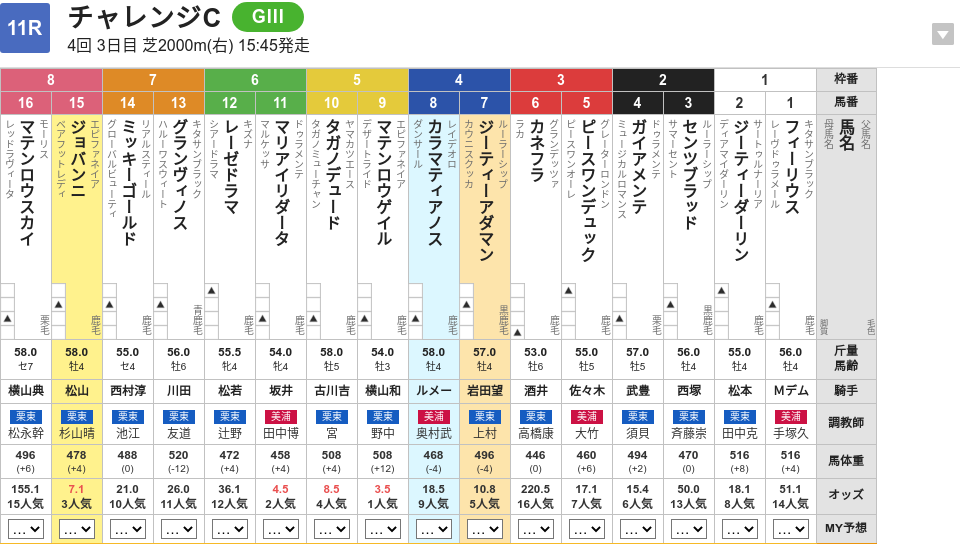

### 【セントライト記念 2026/09/13(日) 】

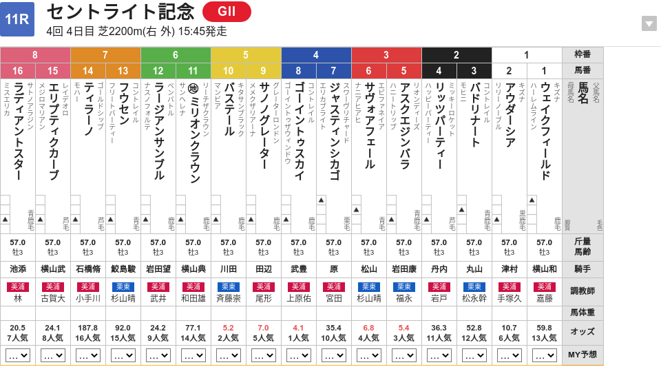

### 【ローズステークス 2026/09/13(日) 】

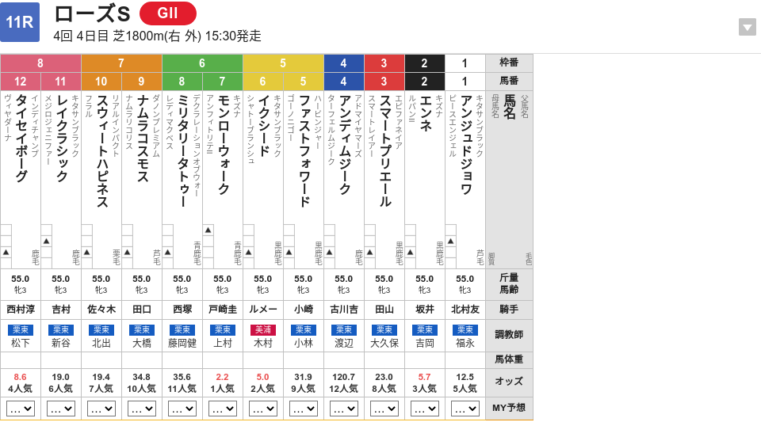

## 4. 単勝予測結果

### 【チャレンジカップ(GⅢ) 2026/09/12(土)】

| 枠番 | 馬番 | 人気 | オッズ | 馬名 | 騎手 | 調教師 | 予測タイム(sec) | 1_順位 | 1-3着内確率(%) | 2_順位 | ﾀﾞｰｸﾎｰｽ確率(%) | 3_順位 |
| --- | --- | --- | --- | --- | --- | --- | --- | --- | --- | --- | --- | --- |
| 1 | 1 | 14 | 51.1 | フィーリウス | Ｍ．デムーロ | 手塚貴久 | 118.9 | 10.5 | 8.4 | 12 | 58.8 | 1 |
| 1 | 2 | 8 | 18.1 | ジーティーダーリン | 松本大輝 | 田中克典 | 121.5 | 15.0 | 10.6 | 10 | 0.9 | 11 |
| 2 | 3 | 13 | 50.0 | センツブラッド | 西塚洸二 | 斉藤崇史 | 118.9 | 10.5 | 8.5 | 11 | 47.8 | 2 |
| 2 | 4 | 6 | 15.4 | ガイアメンテ | 武豊 | 須貝尚介 | 110.0 | 4.0 | 35.9 | 1 | 2.1 | 10 |
| 3 | 5 | 7 | 17.1 | ピースワンデュック | 佐々木大輔 | 大竹正博 | 113.3 | 5.0 | 32.2 | 2 | 2.5 | 9 |
| 3 | 6 | 16 | 220.5 | カネフラ | 酒井学 | 高橋康之 | 124.0 | 16.0 | 2.1 | 15 | 17.0 | 7 |
| 4 | 7 | 5 | 10.8 | ジーティーアダマン | 岩田望来 | 上村洋行 | 118.8 | 7.5 | 21.7 | 4 | 0.5 | 14 |
| 4 | 8 | 9 | 18.5 | カラマティアノス | Ｃ．ルメール | 奥村武 | 118.8 | 7.5 | 15.7 | 6 | 42.1 | 4 |
| 5 | 9 | 1 | 3.5 | マテンロウゲイル | 横山和生 | 野中賢二 | 105.9 | 2.0 | 13.5 | 9 | 0.8 | 12 |
| 5 | 10 | 4 | 8.5 | タガノデュード | 古川吉洋 | 宮徹 | 121.0 | 14.0 | 13.6 | 8 | 0.5 | 15 |

[output cut: 6 more lines]

### 【セントライト記念(GⅡ) 2026/09/13(日)】

| 枠番 | 馬番 | 人気 | オッズ | 馬名 | 騎手 | 調教師 | 予測タイム(sec) | 1_順位 | 1-3着内確率(%) | 2_順位 | ﾀﾞｰｸﾎｰｽ確率(%) | 3_順位 |
| --- | --- | --- | --- | --- | --- | --- | --- | --- | --- | --- | --- | --- |
| 1 | 1 | 13 | 60.1 | ウェイクフィールド | 横山和生 | 嘉藤貴行 | 139.9 | 13.0 | 6.5 | 15 | 17.3 | 8 |
| 1 | 2 | 6 | 10.7 | アウダーシア | 津村明秀 | 手塚貴久 | 134.4 | 3.0 | 42.5 | 1 | 1.1 | 11 |
| 2 | 3 | 12 | 54.1 | バドリナート | 丸山元気 | 松永幹夫 | 139.2 | 5.0 | 10.3 | 11 | 54.6 | 5 |
| 2 | 4 | 11 | 37.3 | リッツパーティー | 丹内祐次 | 岩戸孝樹 | 139.9 | 14.0 | 9.4 | 13 | 52.9 | 6 |
| 3 | 5 | 3 | 5.3 | アスクエジンバラ | 岩田康誠 | 福永祐一 | 139.4 | 7.5 | 31.1 | 2 | 0.7 | 12 |
| 3 | 6 | 4 | 6.7 | サヴォアフェール | 松山弘平 | 杉山晴紀 | 139.8 | 11.0 | 26.3 | 5 | 0.7 | 14 |
| 4 | 7 | 10 | 35.2 | ジャスティンシカゴ | 原優介 | 宮田敬介 | 139.2 | 5.0 | 20.2 | 8 | 54.9 | 4 |
| 4 | 8 | 1 | 4.1 | ゴーイントゥスカイ | 武豊 | 上原佑紀 | 131.5 | 1.5 | 22.9 | 7 | 0.7 | 13 |
| 5 | 9 | 5 | 7.3 | サノノグレーター | 田辺裕信 | 尾形和幸 | 139.4 | 7.5 | 25.4 | 6 | 0.7 | 15 |
| 5 | 10 | 2 | 5.1 | バステール | 川田将雅 | 斉藤崇史 | 139.5 | 9.0 | 27.0 | 4 | 0.7 | 16 |

[output cut: 6 more lines]

### 【ローズステークス(GⅡ) 2026/09/13(日)】

| 枠番 | 馬番 | 人気 | オッズ | 馬名 | 騎手 | 調教師 | 予測タイム(sec) | 1_順位 | 1-3着内確率(%) | 2_順位 | ﾀﾞｰｸﾎｰｽ確率(%) | 3_順位 |
| --- | --- | --- | --- | --- | --- | --- | --- | --- | --- | --- | --- | --- |
| 1 | 1 | 5 | 12.2 | アンジュドジョワ | 北村友一 | 福永祐一 | 107.3 | 2 | 15.6 | 4 | 1.2 | 7 |
| 2 | 2 | 3 | 5.7 | エンネ | 坂井瑠星 | 吉岡辰弥 | 108.3 | 3 | 29.9 | 2 | 1.1 | 8 |
| 3 | 3 | 8 | 23.9 | スマートプリエール | 田山旺佑 | 大久保龍志 | 108.3 | 4 | 6.7 | 6 | 33.6 | 2 |
| 4 | 4 | 12 | 126.6 | アンディムジーク | 古川吉洋 | 渡辺薫彦 | 117.6 | 9 | 2.3 | 12 | 14.5 | 5 |
| 5 | 5 | 9 | 33.3 | ファストフォワード | 小崎綾也 | 小林真也 | 121.3 | 12 | 6.3 | 7 | 12.9 | 6 |
| 5 | 6 | 2 | 5.1 | イクシード | Ｃ．ルメール | 木村哲也 | 109.3 | 7 | 37.1 | 1 | 1.0 | 9 |
| 6 | 7 | 1 | 2.2 | モンローウォーク | 戸崎圭太 | 上村洋行 | 104.4 | 1 | 13.1 | 5 | 0.5 | 12 |
| 6 | 8 | 11 | 36.8 | ミリタリータトゥー | 西塚洸二 | 藤岡健一 | 110.4 | 8 | 5.4 | 9 | 61.0 | 1 |
| 7 | 9 | 10 | 34.8 | ナムラコスモス | 田口貫太 | 大橋勇樹 | 117.8 | 10 | 3.6 | 11 | 23.7 | 4 |
| 7 | 10 | 7 | 19.8 | スウィートハピネス | 佐々木大輔 | 北出成人 | 108.6 | 6 | 6.2 | 8 | 27.5 | 3 |

[output cut: 2 more lines]

## 5. 人気と着順の乖離率推移

### 【チャレンジカップ_1990y_2019y】

[interactive chart not shown]

### 【セントライト記念_1990y_2019y】

[interactive chart not shown]

### 【ローズステークス_1990y_2019y】

[interactive chart not shown]

### 【チャレンジカップ_1990y_2019y】

| No | 開催年 | 不整合率(%) | 頭数 | 人気別着順(1-3位) | 人気別着順(全体) |
| --- | --- | --- | --- | --- | --- |
| 30 | 2019 | 46.0 | 12頭 | 2-8-3 | 2\|8\|3\|11\|10\|5\|6\|7\|1\|4\|12\|9 |
| 29 | 2018 | 47.2 | 12頭 | 2-4-5 | 2\|4\|5\|3\|12\|1\|7\|11\|10\|6\|9\|8 |
| 28 | 2017 | 16.3 | 12頭 | 1-5-2 | 1\|5\|2\|3\|11\|6\|9\|7\|8\|10\|4\|12 |
| 27 | 2016 | 26.6 | 18頭 | 9-5-11 | 9\|5\|11\|1\|2\|6\|14\|7\|3\|8\|4\|17\|10\|16\|13\|15\|18\|12 |
| 26 | 2015 | 12.6 | 18頭 | 1-2-11 | 1\|2\|11\|3\|4\|12\|7\|6\|14\|9\|13\|10\|8\|15\|18\|5\|17\|16 |
| 25 | 2014 | 57.3 | 12頭 | 5-9-2 | 5\|9\|2\|6\|7\|3\|11\|4\|1\|8\|12\|10 |
| 24 | 2013 | 26.6 | 16頭 | 5-1-2 | 5\|1\|2\|14\|6\|8\|11\|15\|4\|3\|10\|7\|9\|13\|16\|12 |
| 23 | 2012 | 43.6 | 16頭 | 3-10-7 | 3\|10\|7\|8\|1\|2\|9\|12\|15\|11\|13\|6\|4\|14\|5\|16 |
| 22 | 2011 | 50.6 | 18頭 | 8-2-6 | 8\|2\|6\|7\|12\|3\|10\|4\|5\|9\|18\|14\|1\|13\|15\|16\|11\|17 |
| 21 | 2010 | 51.5 | 16頭 | 7-4-5 | 7\|4\|5\|2\|6\|8\|9\|13\|15\|1\|12\|14\|16\|11\|10\|3 |

[output cut: 20 more lines]

### 【セントライト記念_1990y_2019y】

| No | 開催年 | 不整合率(%) | 頭数 | 人気別着順(1-3位) | 人気別着順(全体) |
| --- | --- | --- | --- | --- | --- |
| 30 | 2019 | 29.2 | 18頭 | 1-8-3 | 1\|8\|3\|5\|2\|6\|14\|17\|16\|15\|11\|13\|12\|4\|10\|7\|9\|18 |
| 29 | 2018 | 31.4 | 15頭 | 4-1-6 | 4\|1\|6\|2\|10\|14\|5\|15\|12\|9\|13\|7\|3\|8\|11 |
| 28 | 2017 | 24.2 | 15頭 | 2-1-3 | 2\|1\|3\|6\|8\|7\|5\|10\|4\|13\|9\|12\|11\|15\|14 |
| 27 | 2016 | 9.9 | 12頭 | 1-2-3 | 1\|2\|3\|11\|8\|5\|4\|10\|7\|6\|12\|9 |
| 26 | 2015 | 53.1 | 15頭 | 6-9-10 | 6\|9\|10\|14\|3\|5\|1\|7\|12\|2\|15\|13\|8\|11\|4 |
| 25 | 2014 | 27.4 | 18頭 | 1-2-10 | 1\|2\|10\|5\|9\|11\|13\|7\|6\|4\|15\|8\|3\|17\|12\|16\|18\|14 |
| 24 | 2013 | 62.4 | 15頭 | 3-5-6 | 3\|5\|6\|12\|2\|4\|9\|11\|14\|10\|8\|7\|1\|15\|13 |
| 23 | 2012 | 28.2 | 17頭 | 1-14-4 | 1\|14\|4\|5\|8\|6\|11\|9\|2\|10\|3\|7\|13\|12\|15\|16\|17 |
| 22 | 2011 | 40.6 | 17頭 | 6-3-1 | 6\|3\|1\|2\|8\|10\|15\|14\|9\|11\|4\|17\|12\|7\|16\|13\|5 |
| 21 | 2010 | 65.0 | 17頭 | 4-3-2 | 4\|3\|2\|11\|6\|8\|12\|10\|7\|13\|9\|5\|15\|1\|14\|17\|16 |

[output cut: 20 more lines]

### 【ローズステークス_1990y_2019y】

| No | 開催年 | 不整合率(%) | 頭数 | 人気別着順(1-3位) | 人気別着順(全体) |
| --- | --- | --- | --- | --- | --- |
| 30 | 2019 | 18.0 | 12頭 | 1-6-2 | 1\|6\|2\|4\|8\|3\|10\|7\|5\|9\|12\|11 |
| 29 | 2018 | 42.2 | 15頭 | 5-2-13 | 5\|2\|13\|8\|6\|1\|4\|11\|3\|14\|10\|9\|12\|15\|7 |
| 28 | 2017 | 47.4 | 18頭 | 8-6-3 | 8\|6\|3\|5\|12\|1\|2\|17\|4\|13\|15\|7\|11\|9\|18\|10\|14\|16 |
| 27 | 2016 | 39.5 | 15頭 | 1-11-6 | 1\|11\|6\|8\|3\|10\|5\|4\|12\|15\|2\|14\|7\|9\|13 |
| 26 | 2015 | 12.9 | 17頭 | 7-1-2 | 7\|1\|2\|3\|5\|4\|6\|9\|15\|13\|14\|12\|17\|8\|10\|11\|16 |
| 25 | 2014 | 38.7 | 17頭 | 2-15-9 | 2\|15\|9\|6\|4\|1\|7\|13\|3\|8\|12\|16\|14\|10\|5\|11\|17 |
| 24 | 2013 | 46.5 | 18頭 | 1-9-10 | 1\|9\|10\|4\|8\|5\|16\|7\|13\|18\|6\|11\|3\|2\|15\|17\|14\|12 |
| 23 | 2012 | 5.9 | 10頭 | 1-2-3 | 1\|2\|3\|5\|4\|7\|9\|8\|6\|10 |
| 22 | 2011 | 30.1 | 14頭 | 1-10-7 | 1\|10\|7\|4\|5\|2\|11\|6\|9\|3\|8\|14\|12\|13 |
| 21 | 2010 | 38.4 | 12頭 | 4-6-5 | 4\|6\|5\|1\|8\|11\|2\|3\|10\|7\|12\|9 |

[output cut: 20 more lines]

## 6. 1-3番人気馬の着順分類予測

### 【チャレンジカップ】

| 分類 | 凡例 | 発生確率(%) | 当該レース | 当該レースランク | 直近1年間 |
| --- | --- | --- | --- | --- | --- |
| 4: 1,2番人気のみ (4_pop12) | 1 \| 2 \| * | 17.7 | 1.06 | 1.06 | 0.53 |
| 1: 1番人気のみ (1_pop1) | 1 \| * \| * | 17.2 | 2.07 | 2.07 | 0.00 |
| 8: 1,2,3番人気すべて着外 (8_darkhorse) | * \| * \| * | 14.1 | 1.01 | 1.01 | 0.00 |
| 6: 2,3番人気のみ (6_pop23) | 2 \| 3 \| * | 13.5 | 0.49 | 0.49 | 0.41 |
| 5: 1,3番人気のみ (5_pop13) | 1 \| 3 \| * | 12.8 | 2.29 | 2.29 | 0.00 |
| 2: 2番人気のみ (2_pop2) | 2 \| * \| * | 9.3 | 0.56 | 0.56 | 0.00 |
| 3: 3番人気のみ (3_pop3) | 3 \| * \| * | 8.4 | 1.50 | 1.50 | 0.25 |
| 7: 1,2,3番人気すべて着内 (7_pop123) | 1 \| 2 \| 3 | 7.1 | 1.27 | 1.27 | 0.00 |

### 【セントライト記念】

| 分類 | 凡例 | 発生確率(%) | 当該レース | 当該レースランク | 直近1年間 |
| --- | --- | --- | --- | --- | --- |
| 4: 1,2番人気のみ (4_pop12) | 1 \| 2 \| * | 17.7 | 1.27 | 0.67 | 0.35 |
| 1: 1番人気のみ (1_pop1) | 1 \| * \| * | 17.2 | 1.24 | 1.03 | 0.00 |
| 8: 1,2,3番人気すべて着外 (8_darkhorse) | * \| * \| * | 14.1 | 1.70 | 1.70 | 0.00 |
| 6: 2,3番人気のみ (6_pop23) | 2 \| 3 \| * | 13.5 | 2.41 | 2.41 | 0.00 |
| 5: 1,3番人気のみ (5_pop13) | 1 \| 3 \| * | 12.8 | 1.54 | 1.86 | 0.00 |
| 2: 2番人気のみ (2_pop2) | 2 \| * \| * | 9.3 | 1.66 | 1.12 | 0.00 |
| 3: 3番人気のみ (3_pop3) | 3 \| * \| * | 8.4 | 0.20 | 0.38 | 0.17 |
| 7: 1,2,3番人気すべて着内 (7_pop123) | 1 \| 2 \| 3 | 7.1 | 2.54 | 1.27 | 0.00 |

### 【ローズステークス】

| 分類 | 凡例 | 発生確率(%) | 当該レース | 当該レースランク | 直近1年間 |
| --- | --- | --- | --- | --- | --- |
| 4: 1,2番人気のみ (4_pop12) | 1 \| 2 \| * | 17.6 | 0.45 | 0.67 | 0.35 |
| 1: 1番人気のみ (1_pop1) | 1 \| * \| * | 17.3 | 0.89 | 1.04 | 0.00 |
| 3: 3番人気のみ (3_pop3) | 3 \| * \| * | 13.8 | 4.93 | 0.62 | 0.28 |
| 5: 1,3番人気のみ (5_pop13) | 1 \| 3 \| * | 13.4 | 2.39 | 1.94 | 0.00 |
| 8: 1,2,3番人気すべて着外 (8_darkhorse) | * \| * \| * | 12.9 | 1.55 | 1.55 | 0.00 |
| 2: 2番人気のみ (2_pop2) | 2 \| * \| * | 9.4 | 0.85 | 1.13 | 0.00 |
| 6: 2,3番人気のみ (6_pop23) | 2 \| 3 \| * | 8.5 | 1.52 | 1.52 | 0.00 |
| 7: 1,2,3番人気すべて着内 (7_pop123) | 1 \| 2 \| 3 | 7.1 | 0.86 | 1.27 | 0.00 |

## 7. 3連複予測結果

### 【チャレンジカップ(GⅢ) 2026/09/12(土)】

| 分類 | 馬番 | 枠番 | 人気 | 平均予測タイム(sec) | 1-3着内確率(%) | ﾀﾞｰｸﾎｰｽ確率(%) | 馬名 | 騎手 | 調教師 |
| --- | --- | --- | --- | --- | --- | --- | --- | --- | --- |
| 2: 2番人気のみ (2_pop2) | 11-4-5 | 6-2-3 | 2-6-7 | 113.83 | 3.50 | 0.00 | マリアイリダータ \| ガイアメンテ \| ピースワンデュック | 坂井瑠星 \| 武豊 \| 佐々木大輔 | 田中博康 \| 須貝尚介 \| 大竹正博 |
| 8: 1,2,3番人気すべて着外 (8_darkhorse) | 7-4-5 | 4-2-3 | 5-6-7 | 114.03 | 2.50 | 0.00 | ジーティーアダマン \| ガイアメンテ \| ピースワンデュック | 岩田望来 \| 武豊 \| 佐々木大輔 | 上村洋行 \| 須貝尚介 \| 大竹正博 |
| 2: 2番人気のみ (2_pop2) | 11-7-4 | 6-4-2 | 2-5-6 | 115.67 | 2.36 | 0.00 | マリアイリダータ \| ジーティーアダマン \| ガイアメンテ | 坂井瑠星 \| 岩田望来 \| 武豊 | 田中博康 \| 上村洋行 \| 須貝尚介 |
| 8: 1,2,3番人気すべて着外 (8_darkhorse) | 4-5-13 | 2-3-7 | 6-7-11 | 109.73 | 2.16 | 0.02 | ガイアメンテ \| ピースワンデュック \| グランヴィノス | 武豊 \| 佐々木大輔 \| 川田将雅 | 須貝尚介 \| 大竹正博 \| 友道康夫 |
| 2: 2番人気のみ (2_pop2) | 11-7-5 | 6-4-3 | 2-5-7 | 116.77 | 2.12 | 0.00 | マリアイリダータ \| ジーティーアダマン \| ピースワンデュック | 坂井瑠星 \| 岩田望来 \| 佐々木大輔 | 田中博康 \| 上村洋行 \| 大竹正博 |
| 2: 2番人気のみ (2_pop2) | 11-4-13 | 6-2-7 | 2-6-11 | 111.37 | 2.04 | 0.00 | マリアイリダータ \| ガイアメンテ \| グランヴィノス | 坂井瑠星 \| 武豊 \| 川田将雅 | 田中博康 \| 須貝尚介 \| 友道康夫 |
| 2: 2番人気のみ (2_pop2) | 11-5-13 | 6-3-7 | 2-7-11 | 112.47 | 1.83 | 0.01 | マリアイリダータ \| ピースワンデュック \| グランヴィノス | 坂井瑠星 \| 佐々木大輔 \| 川田将雅 | 田中博康 \| 大竹正博 \| 友道康夫 |
| 8: 1,2,3番人気すべて着外 (8_darkhorse) | 4-5-8 | 2-3-4 | 6-7-9 | 114.03 | 1.81 | 0.02 | ガイアメンテ \| ピースワンデュック \| カラマティアノス | 武豊 \| 佐々木大輔 \| Ｃ．ルメール | 須貝尚介 \| 大竹正博 \| 奥村武 |
| 3: 3番人気のみ (3_pop3) | 15-4-5 | 8-2-3 | 3-6-7 | 114.40 | 1.79 | 0.00 | ジョバンニ \| ガイアメンテ \| ピースワンデュック | 松山弘平 \| 武豊 \| 佐々木大輔 | 杉山晴紀 \| 須貝尚介 \| 大竹正博 |
| 2: 2番人気のみ (2_pop2) | 11-4-8 | 6-2-4 | 2-6-9 | 115.67 | 1.71 | 0.01 | マリアイリダータ \| ガイアメンテ \| カラマティアノス | 坂井瑠星 \| 武豊 \| Ｃ．ルメール | 田中博康 \| 須貝尚介 \| 奥村武 |

[output cut: 550 more lines]

### 【セントライト記念(GⅡ) 2026/09/13(日)】

| 分類 | 馬番 | 枠番 | 人気 | 平均予測タイム(sec) | 1-3着内確率(%) | ﾀﾞｰｸﾎｰｽ確率(%) | 馬名 | 騎手 | 調教師 |
| --- | --- | --- | --- | --- | --- | --- | --- | --- | --- |
| 3: 3番人気のみ (3_pop3) | 5-2-15 | 3-1-8 | 3-6-9 | 135.10 | 3.77 | 0.00 | アスクエジンバラ \| アウダーシア \| エリプティクカーブ | 岩田康誠 \| 津村明秀 \| 横山武史 | 福永祐一 \| 手塚貴久 \| 古賀大生 |
| 6: 2,3番人気のみ (6_pop23) | 10-5-2 | 5-3-1 | 2-3-6 | 137.77 | 3.57 | 0.00 | バステール \| アスクエジンバラ \| アウダーシア | 川田将雅 \| 岩田康誠 \| 津村明秀 | 斉藤崇史 \| 福永祐一 \| 手塚貴久 |
| 3: 3番人気のみ (3_pop3) | 5-6-2 | 3-3-1 | 3-4-6 | 137.87 | 3.48 | 0.00 | アスクエジンバラ \| サヴォアフェール \| アウダーシア | 岩田康誠 \| 松山弘平 \| 津村明秀 | 福永祐一 \| 杉山晴紀 \| 手塚貴久 |
| 3: 3番人気のみ (3_pop3) | 5-9-2 | 3-5-1 | 3-5-6 | 137.73 | 3.36 | 0.00 | アスクエジンバラ \| サノノグレーター \| アウダーシア | 岩田康誠 \| 田辺裕信 \| 津村明秀 | 福永祐一 \| 尾形和幸 \| 手塚貴久 |
| 2: 2番人気のみ (2_pop2) | 10-2-15 | 5-1-8 | 2-6-9 | 135.13 | 3.27 | 0.00 | バステール \| アウダーシア \| エリプティクカーブ | 川田将雅 \| 津村明秀 \| 横山武史 | 斉藤崇史 \| 手塚貴久 \| 古賀大生 |
| 8: 1,2,3番人気すべて着外 (8_darkhorse) | 6-2-15 | 3-1-8 | 4-6-9 | 135.23 | 3.18 | 0.00 | サヴォアフェール \| アウダーシア \| エリプティクカーブ | 松山弘平 \| 津村明秀 \| 横山武史 | 杉山晴紀 \| 手塚貴久 \| 古賀大生 |
| 8: 1,2,3番人気すべて着外 (8_darkhorse) | 9-2-15 | 5-1-8 | 5-6-9 | 135.10 | 3.07 | 0.00 | サノノグレーター \| アウダーシア \| エリプティクカーブ | 田辺裕信 \| 津村明秀 \| 横山武史 | 尾形和幸 \| 手塚貴久 \| 古賀大生 |
| 5: 1,3番人気のみ (5_pop13) | 8-5-2 | 4-3-1 | 1-3-6 | 135.10 | 3.04 | 0.00 | ゴーイントゥスカイ \| アスクエジンバラ \| アウダーシア | 武豊 \| 岩田康誠 \| 津村明秀 | 上原佑紀 \| 福永祐一 \| 手塚貴久 |
| 2: 2番人気のみ (2_pop2) | 10-6-2 | 5-3-1 | 2-4-6 | 137.90 | 3.02 | 0.00 | バステール \| サヴォアフェール \| アウダーシア | 川田将雅 \| 松山弘平 \| 津村明秀 | 斉藤崇史 \| 杉山晴紀 \| 手塚貴久 |
| 2: 2番人気のみ (2_pop2) | 10-9-2 | 5-5-1 | 2-5-6 | 137.77 | 2.91 | 0.00 | バステール \| サノノグレーター \| アウダーシア | 川田将雅 \| 田辺裕信 \| 津村明秀 | 斉藤崇史 \| 尾形和幸 \| 手塚貴久 |

[output cut: 550 more lines]

### 【ローズステークス(GⅡ) 2026/09/13(日)】

| 分類 | 馬番 | 枠番 | 人気 | 平均予測タイム(sec) | 1-3着内確率(%) | ﾀﾞｰｸﾎｰｽ確率(%) | 馬名 | 騎手 | 調教師 |
| --- | --- | --- | --- | --- | --- | --- | --- | --- | --- |
| 6: 2,3番人気のみ (6_pop23) | 6-2-12 | 5-2-8 | 2-3-4 | 108.67 | 2.65 | 0.00 | イクシード \| エンネ \| タイセイボーグ | Ｃ．ルメール \| 坂井瑠星 \| 西村淳也 | 木村哲也 \| 吉岡辰弥 \| 松下武士 |
| 6: 2,3番人気のみ (6_pop23) | 6-2-1 | 5-2-1 | 2-3-5 | 108.30 | 1.73 | 0.00 | イクシード \| エンネ \| アンジュドジョワ | Ｃ．ルメール \| 坂井瑠星 \| 北村友一 | 木村哲也 \| 吉岡辰弥 \| 福永祐一 |
| 7: 1,2,3番人気すべて着内 (7_pop123) | 7-6-2 | 6-5-2 | 1-2-3 | 107.33 | 1.45 | 0.00 | モンローウォーク \| イクシード \| エンネ | 戸崎圭太 \| Ｃ．ルメール \| 坂井瑠星 | 上村洋行 \| 木村哲也 \| 吉岡辰弥 |
| 2: 2番人気のみ (2_pop2) | 6-12-1 | 5-8-1 | 2-4-5 | 108.33 | 1.38 | 0.00 | イクシード \| タイセイボーグ \| アンジュドジョワ | Ｃ．ルメール \| 西村淳也 \| 北村友一 | 木村哲也 \| 松下武士 \| 福永祐一 |
| 4: 1,2番人気のみ (4_pop12) | 7-6-12 | 6-5-8 | 1-2-4 | 107.37 | 1.16 | 0.00 | モンローウォーク \| イクシード \| タイセイボーグ | 戸崎圭太 \| Ｃ．ルメール \| 西村淳也 | 上村洋行 \| 木村哲也 \| 松下武士 |
| 3: 3番人気のみ (3_pop3) | 2-12-1 | 2-8-1 | 3-4-5 | 108.00 | 1.11 | 0.00 | エンネ \| タイセイボーグ \| アンジュドジョワ | 坂井瑠星 \| 西村淳也 \| 北村友一 | 吉岡辰弥 \| 松下武士 \| 福永祐一 |
| 5: 1,3番人気のみ (5_pop13) | 7-2-12 | 6-2-8 | 1-3-4 | 107.03 | 0.93 | 0.00 | モンローウォーク \| エンネ \| タイセイボーグ | 戸崎圭太 \| 坂井瑠星 \| 西村淳也 | 上村洋行 \| 吉岡辰弥 \| 松下武士 |
| 4: 1,2番人気のみ (4_pop12) | 7-6-1 | 6-5-1 | 1-2-5 | 107.00 | 0.76 | 0.00 | モンローウォーク \| イクシード \| アンジュドジョワ | 戸崎圭太 \| Ｃ．ルメール \| 北村友一 | 上村洋行 \| 木村哲也 \| 福永祐一 |
| 6: 2,3番人気のみ (6_pop23) | 6-2-3 | 5-2-3 | 2-3-8 | 108.63 | 0.75 | 0.00 | イクシード \| エンネ \| スマートプリエール | Ｃ．ルメール \| 坂井瑠星 \| 田山旺佑 | 木村哲也 \| 吉岡辰弥 \| 大久保龍志 |
| 6: 2,3番人気のみ (6_pop23) | 6-2-5 | 5-2-5 | 2-3-9 | 112.97 | 0.70 | 0.00 | イクシード \| エンネ \| ファストフォワード | Ｃ．ルメール \| 坂井瑠星 \| 小崎綾也 | 木村哲也 \| 吉岡辰弥 \| 小林真也 |

[output cut: 210 more lines]

## 8. 直近の全レース情報

[output not shown]